# Financial Analytics

## 10 · News Impact Curve: GARCH vs EGARCH

**Nota**

**GARCH:** curva **simétrica**, mesmo impacto para choques positivos e negativos.  
**EGARCH:** curva **assimétrica**, bad news amplifica mais a volatilidade (*leverage effect*).

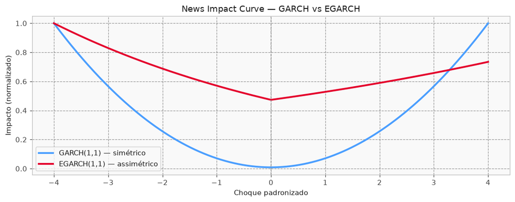

## 10 · News Impact Curve: GARCH vs EGARCH

O que significam os eixos?

• Eixo Horizontal (Choque padronizado): Representa a surpresa ou “notícia” do mercado. Valores negativos (à esquerda do 0) são notícias ruins ou quedas inesperadas, e valores positivos (à direita do 0) são notícias boas ou altas inesperadas.

• Eixo Vertical (Impacto normalizado): Representa o tamanho da volatilidade (agitação ou risco) gerada no mercado após a notícia, variando de 0.0 (baixo impacto) até 1.0 (impacto máximo).

*Comparação entre os dois modelos*

**Garch:** Reação a notícias Uma notícia ruim de tamanho -4 gera exatamente o mesmo impacto (1.0) que uma notícia boa de tamanho +4.

**E-Garch:** Uma notícia ruim de tamanho -4 gera impacto máximo (1.0), mas uma notícia boa de +4 gera bem menos impacto (cerca de 0.74), o chamado efeito alavancagem (o mercado reage mais forte ao medo do que à euforia).

## 10 · Modelo TGARCH (GJR-GARCH)

$$h_t = \alpha_0 + \alpha_1 r_{t-1}^2 + \gamma r_{t-1}^2 d_{t-1} + \beta_1 h_{t-1}$$

```python
# TGARCH via arch (GJR-GARCH)
m7 = arch_model(ret, mean='Constant', vol='GARCH', p=1, o=1, q=1, dist='normal')
res7 = m7.fit(disp='off')
print(res7.params)
# gamma[1] > 0 → bad news adiciona impacto extra
```

## 11 · Volatilidade Estocástica (SV)

$$r_t = \exp(h_t/2)\,\varepsilon_t \qquad h_t = \mu + \phi\,(h_{t-1} - \mu) + \sigma\,\eta_t$$

```python
# Transformação: log(r_t²) ≈ h_t + kappa_t
log_r2 = np.log(ret**2 + 1e-10)

phi_sv, sigma_sv, mu_sv = 0.97, 0.15, log_r2.mean()

h_filt = np.zeros(len(ret)); P_filt = np.zeros(len(ret))
h_pred = mu_sv
P_pred = sigma_sv**2 / (1 - phi_sv**2)
KAPPA  = -1.2704
V_obs  = np.pi**2 / 2

for t, y in enumerate(log_r2):
    K         = P_pred / (P_pred + V_obs)
    h_filt[t] = h_pred + K * (y - h_pred - KAPPA)
    P_filt[t] = (1 - K) * P_pred
    h_pred    = mu_sv + phi_sv * (h_filt[t] - mu_sv)
    P_pred    = phi_sv**2 * P_filt[t] + sigma_sv**2

vol_sv    = np.exp(h_filt / 2)
vol_sv_hi = np.exp((h_filt + 1.96 * np.sqrt(P_filt)) / 2)
vol_sv_lo = np.exp((h_filt - 1.96 * np.sqrt(P_filt)) / 2)

print(f"Vol SV | média: {vol_sv.mean():.4f}  máx: {vol_sv.max():.4f}")
print(f"Vol GARCH | média: {res4.conditional_volatility.mean():.4f}")
```

## 11 · SV vs GARCH: Volatilidade Estimada

**Nota**

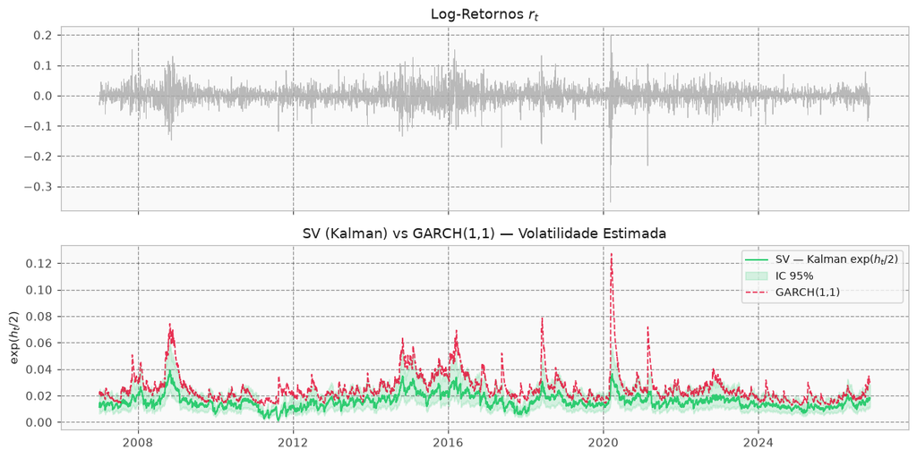

## 🏋️ Exercício Proposto

1. Baixe dados de **VALE3.SA** ou **^BVSP** via `yfinance` (2007-hoje)
2. Calcule os log-retornos e verifique os **3 fatos estilizados**
3. Compare curtose e assimetria com os valores da PETR4.SA
4. Aplique os **testes Ljung-Box e LM**, há efeitos ARCH?
5. Ajuste **ARCH(12)** e **GARCH(1,1)** com Normal e t-Student
6. Compare via **AIC/BIC**, qual modelo vence?
7. Verifique o diagnóstico, os efeitos ARCH foram removidos?
8. **Bônus:** ajuste EGARCH(1,1), há efeito de alavancagem ($\gamma \neq 0$)?

## 📖 Referências

**Análise de Séries Temporais Financeiras**, Tsay (2010)  
Caps. 3-4 (ARCH/GARCH) e Cap. 12 (Volatilidade Estocástica)

**arch: ARCH and GARCH Models (Python)**  
🔗 [arch.readthedocs.io](https://arch.readthedocs.io/)

**yfinance: Yahoo Finance Market Data**  
🔗 [pypi.org/project/yfinance](https://pypi.org/project/yfinance/)

**Material do curso**, PADS Insper 2026  
🔗 [padsinsper.github.io/202634-fa](https://padsinsper.github.io/202634-fa/)

# Dúvidas?

*Financial Analytics · PADS · Insper · 2026*